# LBB Data Visualization Electric Vehicle

Muh Amri Sidiq

2023-07-07

# Introduction

The definition or definition of an electric car is a vehicle that is fully or partially driven by a motor using electricity in a battery. The battery is rechargeable. In this data, there are 2 types of batteries, namely plug-in electric hybrid vehicle (PHEV) and battery electric vehicle (BEV)This data is taken from https://catalog.data.gov/dataset/electric-vehicle-population-data.

# Data Preprocessing

## Import Dataset

We can import data and type data we use csv file

```r
# Read data
EV_Population <- read.csv("Electric_Vehicle_Population_Data.csv")
```

## Data Inspection

we use head to see at a glance the contents of the data

```r
# Inspection data
head(EV_Population)
```

|  | VIN..1.10. | County | City | State | Postal.Code | Model.Year | Make | Model | Electric.Vehicle.Type | Clean.Alternative.Fuel.Vehicle..CAFV..Eligibility | Electric.Range | Base.MSRP | Legislative.District | DOL.Vehicle.ID | Vehicle.Location | Electric.Utility | X2020.Census.Tract |
| --- | --- | --- | --- | --- | --- | --- | --- | --- | --- | --- | --- | --- | --- | --- | --- | --- | --- |
| 1 | 5YJ3E1EA0K | Thurston | Tumwater | WA | 98512 | 2019 | TESLA | MODEL 3 | Battery Electric Vehicle (BEV) | Clean Alternative Fuel Vehicle Eligible | 220 | 0 | 22 | 242565116 | POINT (-122.91310169999997 47.01359260000004) | PUGET SOUND ENERGY INC | 53067010910 |
| 2 | 1N4BZ1DV4N | Island | Clinton | WA | 98236 | 2022 | NISSAN | LEAF | Battery Electric Vehicle (BEV) | Eligibility unknown as battery range has not been researched | 0 | 0 | 10 | 183272785 | POINT (-122.35936399999997 47.97965520000008) | PUGET SOUND ENERGY INC | 53029972000 |
| 3 | 5YJ3E1EA0L | Snohomish | Snohomish | WA | 98290 | 2020 | TESLA | MODEL 3 | Battery Electric Vehicle (BEV) | Clean Alternative Fuel Vehicle Eligible | 266 | 0 | 44 | 112552366 | POINT (-122.09150499999998 47.91555500000004) | PUGET SOUND ENERGY INC | 53061052502 |
| 4 | 5YJ3E1EBXL | King | Seattle | WA | 98134 | 2020 | TESLA | MODEL 3 | Battery Electric Vehicle (BEV) | Clean Alternative Fuel Vehicle Eligible | 322 | 0 | 11 | 6336319 | POINT (-122.32981499999994 47.579810000000066) | CITY OF SEATTLE - (WA)\|CITY OF TACOMA - (WA) | 53033009300 |
| 5 | 5YJSA1CP0D | Snohomish | Edmonds | WA | 98020 | 2013 | TESLA | MODEL S | Battery Electric Vehicle (BEV) | Clean Alternative Fuel Vehicle Eligible | 208 | 69900 | 21 | 186212960 | POINT (-122.37507 47.80807000000004) | PUGET SOUND ENERGY INC | 53061050403 |
| 6 | WBY7Z8C5XJ | Chelan | Manson | WA | 98831 | 2018 | BMW | I3 | Plug-in Hybrid Electric Vehicle (PHEV) | Clean Alternative Fuel Vehicle Eligible | 97 | 0 | 12 | 215122904 | POINT (-120.1531 47.88550500000008) | PUD NO 1 OF CHELAN COUNTY | 53007960400 |

To see the data structure we use library Tidyverse

```r
library(tidyverse)
```

```r
# Check data
glimpse(EV_Population)
```

```
#> Rows: 135,038
#> Columns: 17
#> $ VIN..1.10.                                        <chr> "5YJ3E1EA0K", "1N4BZ…
#> $ County                                            <chr> "Thurston", "Island"…
#> $ City                                              <chr> "Tumwater", "Clinton…
#> $ State                                             <chr> "WA", "WA", "WA", "W…
#> $ Postal.Code                                       <int> 98512, 98236, 98290,…
#> $ Model.Year                                        <int> 2019, 2022, 2020, 20…
#> $ Make                                              <chr> "TESLA", "NISSAN", "…
#> $ Model                                             <chr> "MODEL 3", "LEAF", "…
#> $ Electric.Vehicle.Type                             <chr> "Battery Electric Ve…
#> $ Clean.Alternative.Fuel.Vehicle..CAFV..Eligibility <chr> "Clean Alternative F…
#> $ Electric.Range                                    <int> 220, 0, 266, 322, 20…
#> $ Base.MSRP                                         <int> 0, 0, 0, 0, 69900, 0…
#> $ Legislative.District                              <int> 22, 10, 44, 11, 21, …
#> $ DOL.Vehicle.ID                                    <int> 242565116, 183272785…
#> $ Vehicle.Location                                  <chr> "POINT (-122.9131016…
#> $ Electric.Utility                                  <chr> "PUGET SOUND ENERGY …
#> $ X2020.Census.Tract                                <dbl> 53067010910, 5302997…
```

This data use 17 coloumns and 135.038 row, Data from https://catalog.data.gov/dataset/electric-vehicle-population-data. Explain coloumn this below:

```
-  VIN (1-10) = The 1st 10 characters of each vehicle's Vehicle Identification Number (VIN).
- County = This is the geographic region of a state that a vehicle's owner is listed to reside within. Vehicles registered in Washington state may be located in other states
- City = The city in which the registered owner resides.
- State = This is the geographic region of the country associated with the record. These addresses may be located in other states.
- Postal Code = The 5 digit zip code in which the registered owner resides.
- Model Year =  The model year of the vehicle, determined by decoding the Vehicle Identification Number (VIN).
- Make = The manufacturer of the vehicle, determined by decoding the Vehicle Identification Number (VIN).
- Model = The model of the vehicle, determined by decoding the Vehicle Identification Number (VIN).
- Electric Vehicle Type = This distinguishes the vehicle as all electric or a plug-in hybrid.
- Clean Alternative Fuel Vehicle (CAFV) Eligibility = This categorizes vehicle as Clean Alternative Fuel Vehicles (CAFVs) based on the fuel requirement and electric-only range requirement in House Bill 2042 as passed in the 2019 legislative session.
- Electric Range = Describes how far a vehicle can travel purely on its electric charge.
- Base MSRP = This is the lowest Manufacturer's Suggested Retail Price (MSRP) for any trim level of the model in question.
- Legislative District = The specific section of Washington State that the vehicle's owner resides in, as represented in the state legislature.
- DOL Vehicle ID = Unique number assigned to each vehicle by Department of Licensing for identification purposes.
- Vehicle Location = The center of the ZIP Code for the registered vehicle.
- Electric Utility = This is the electric power retail service territories serving the address of the registered vehicle
- 2020 Census Tract = The census tract identifier is a combination of the state, county, and census tract codes as assigned by the United States Census Bureau in the 2020 census, also known as Geographic Identifier (GEOID)
```

## Cleaning Data

for this case we do not use all columns. we will only use columns according to the case we are going to solve

```r
# Delete coloumn
EV_Population_Clean <-  select(EV_Population,
       -State,
       -Postal.Code,
       -Legislative.District,
       -Vehicle.Location,
       -X2020.Census.Tract)
```

Check Missing values

```r
# Find missing values
colSums(is.na(EV_Population_Clean))
```

```
#>                                        VIN..1.10.
#>                                                 0
#>                                            County
#>                                                 0
#>                                              City
#>                                                 0
#>                                        Model.Year
#>                                                 0
#>                                              Make
#>                                                 0
#>                                             Model
#>                                                 0
#>                             Electric.Vehicle.Type
#>                                                 0
#> Clean.Alternative.Fuel.Vehicle..CAFV..Eligibility
#>                                                 0
#>                                    Electric.Range
#>                                                 1
#>                                         Base.MSRP
#>                                                 1
#>                                    DOL.Vehicle.ID
#>                                                 0
#>                                  Electric.Utility
#>                                                 0
```

we can fill in the missing values with 0

```r
# Treatment missing value
EV_Population_Clean[is.na(EV_Population_Clean)] <- 0
```

To make it easier to mention the column, we change the name of the column

```r
# Change coloumn name
colnames(EV_Population_Clean)[7] <- "EV_Type"
colnames(EV_Population_Clean)[8] <- "CAFV"
```

## Change Data Type

In this case we must change type data. Conversion into correct data type contributes to memory saving and enable data manipulation using specific function designed for each datatype.

```r
# Change type data
EV_Population_Clean <- mutate(EV_Population_Clean,
                              County = as.factor(County),
                              City = as.factor(City),
                              Make = as.factor(Make),
                              Model = as.factor(Model))
```

# Exploratory Data

using summary() to extract the basic statistical information of each column in our EV_Population_Clean dataframe.

```r
# Check summary data
summary(EV_Population_Clean)
```

```
#>   VIN..1.10.              County             City         Model.Year
#>  Length:135038      King     :70842   Seattle  :23489   Min.   :1997
#>  Class :character   Snohomish:15258   Bellevue : 6960   1st Qu.:2018
#>  Mode  :character   Pierce   :10410   Redmond  : 4965   Median :2021
#>                     Clark    : 7997   Vancouver: 4819   Mean   :2020
#>                     Thurston : 4851   Kirkland : 4201   3rd Qu.:2022
#>                     Kitsap   : 4461   Bothell  : 4196   Max.   :2024
#>                     (Other)  :21219   (Other)  :86408
#>         Make           Model         EV_Type              CAFV
#>  TESLA    :61808   MODEL 3:25837   Length:135038      Length:135038
#>  NISSAN   :13150   MODEL Y:23577   Class :character   Class :character
#>  CHEVROLET:11437   LEAF   :13020   Mode  :character   Mode  :character
#>  FORD     : 6897   MODEL S: 7473
#>  BMW      : 5895   BOLT EV: 5419
#>  KIA      : 5491   VOLT   : 4881
#>  (Other)  :30360   (Other):54831
#>  Electric.Range     Base.MSRP      DOL.Vehicle.ID      Electric.Utility
#>  Min.   :  0.00   Min.   :     0   Min.   :     4385   Length:135038
#>  1st Qu.:  0.00   1st Qu.:     0   1st Qu.:160630473   Class :character
#>  Median : 21.00   Median :     0   Median :205956344   Mode  :character
#>  Mean   : 74.59   Mean   :  1448   Mean   :206343192
#>  3rd Qu.:150.00   3rd Qu.:     0   3rd Qu.:230888831
#>  Max.   :337.00   Max.   :845000   Max.   :479254772
#>
```

from the data summary we can draw conclusions, for the electrical range the mean is 74.59 and for the base MSRP the mean is 1448

## Distribution Analysis

We can sea King county is most count electric vehicle, we can use histogram for distribution analysis

```r
library(ggplot2)
```

```r
# Aggregation data for county King
EV_Make <- EV_Population_Clean %>% filter(County == "King" & Electric.Range > 0) %>%
            group_by(Make, Electric.Range) %>%
  summarise(count_make = n(),.groups = "drop") %>%
  arrange(-count_make)
```

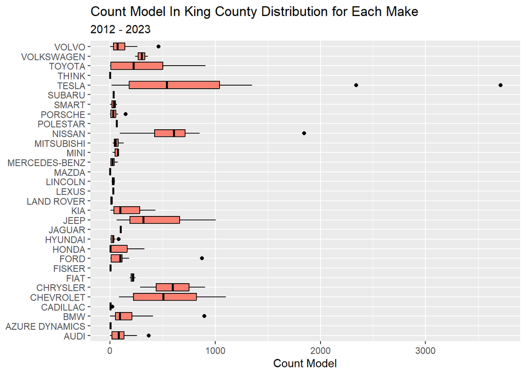

```r
# Plot from EV_Make
ggplot(data = EV_Make, mapping = aes(x = count_make, y = Make)) +
  geom_boxplot(fill = "salmon", col = "black") +
  labs(
    title = "Count Model In King County Distribution for Each Make",
    subtitle = "2012 - 2023",
    x = "Count Model",
    y = NULL
  )
```

The most use electrical vehicle is TESLA

```r
# Aggregation data for county King
EV_County_king <- EV_Population_Clean %>% filter(County == "King" & Electric.Range > 0) %>%
            group_by(Model) %>% summarise(count_ev = n()) %>%
  arrange(-count_ev) %>%
  head(10)
```

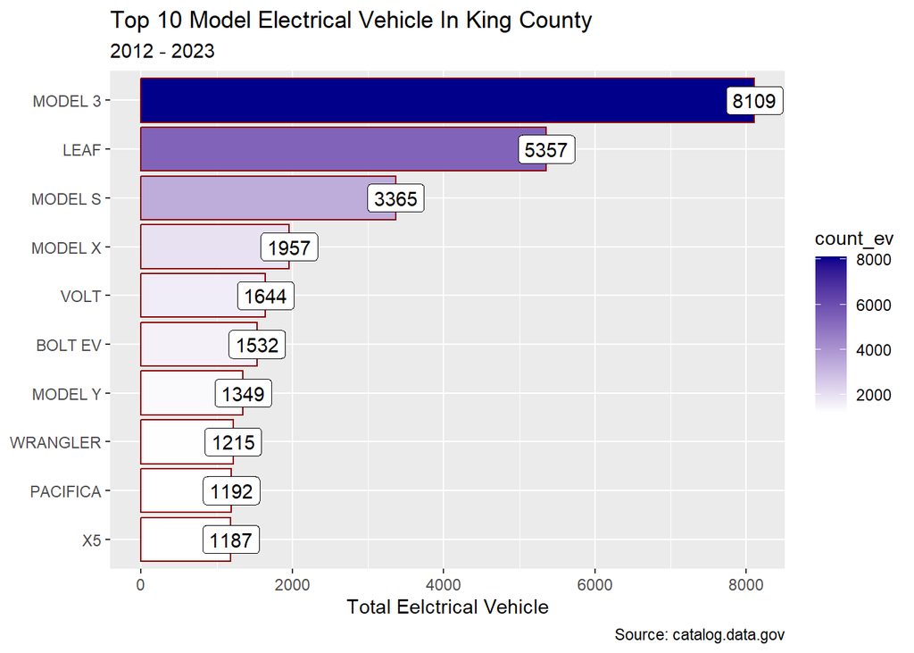

```r
# Plot form EV_County_king
ggplot(data = EV_County_king, mapping = aes(x = count_ev, y = reorder(Model, count_ev))) +
  geom_col(aes(fill = count_ev), col = "darkred") +
  scale_fill_gradient(low="white", high="darkblue")+
  geom_label(aes(label = count_ev)) +
  labs(
     title = "Top 10 Model Electrical Vehicle In King County",
     subtitle = "2012 - 2023",
     x = "Total Eelctrical Vehicle",
     y = NULL,
     caption = "Source: catalog.data.gov"
   )
```

the most electrical vehicle in the KING area is Model 3 (TESLA)

```r
# Aggregation data for county King
EV_king_type <- EV_Population_Clean %>%
  filter(County == "King") %>%
  group_by(Make, EV_Type) %>%
  summarise(count_make = n(),.groups = "drop") %>%
  arrange(-count_make) %>%
  head(10)
```

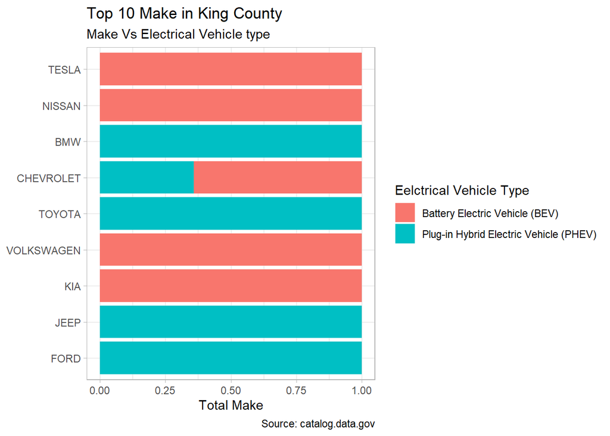

```r
# Plot from EV_king_type
ggplot(EV_king_type, mapping = aes(x = count_make, y = reorder(Make, count_make)))+
  geom_col(aes(fill = EV_Type), position = "fill")+
   labs(
     title = "Top 10 Make in King County",
     subtitle = "Make Vs Electrical Vehicle type",
     x = "Total Make",
     y = NULL,
     fill = "Eelctrical Vehicle Type",
     caption = "Source: catalog.data.gov"
   ) + theme_light()
```

From the histogram above, we can draw insight:TESLA, NISSAN, VOLKSWAGEN, and KIA use Battery Eelectrical Vehicles. BMW, TOYOTA, JEEP and FORD use Plug-in Hybrid Electrical Vehicles. whereas CHEVROLET has both battery types

```r
# Aggregation data for county King
EV_king_cafv <- EV_Population_Clean %>%
  filter(County == "King") %>%
  group_by(Make, CAFV) %>%
  summarise(count_cafv = n(),.groups = "drop") %>%
  arrange(-count_cafv) %>%
  head(10)
```